# snRNA interference revisions

Cait McDonald

Last Updated: 2021-04-09

## Overview

Based on reviewer feedback, our goal is to integrate RNAseq results from Elliott’s PBMC and fibroblast FeLV trial with the transcriptome projects pulled down from NCBI.

In terms of samples we have:

- 6 SPF cats: PBMCs, uninfected only
- 5 outbred cats: fibroblasts, uninfected and infected
- 1 puma: fibroblasts, uninfected and infected

## TL;DR (to date)

- DC1PLUS (fibroblasts) fails. fastq file likely incompletely downloaded.
- Same indexes might have been used for puma and DC4.
- Puma (fibroblasts) likely failed. No sequence duplication.
- See questions section.

## Pipeline (as I understand it)

1. **Sample QC:** fastqc + multiqc of raw RNAseq reads
2. **Trimming & Mapping 1:** Generate indexes of enFeLV from the fasta file that Elliott provided.
3. **Trimming & Mapping 2:** Run Elliott’s cutadapt + bowtie2 script, which I have amended to work with our new reads.
4. **Quantification:** generate read counts mapped to each FeLV index using TMM normalization.

## Sample QC

I’ve generated QC files of each library using this batch script.

All the libraries look okay according to multiqc output, except for:

1. `DC2Pool_NoIndex_L001_I1_001.fastq.gz` and `DC3Pool_NoIndex_L001_I1_001.fastq.gz`, which are only 8bp long instead of 150bp:

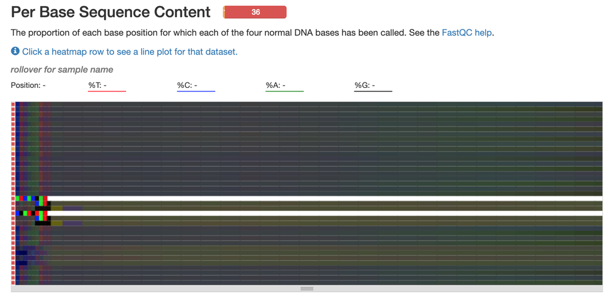

2. `DC1PLUS_S8_L002_R2_001.fastq.gz` seems to have failed sequencing because the file is only 8.8MB. I went back and checked Elliott’s files on CVMRIT03, and it’s the same size there. **It won’t unzip because there’s an ‘unexpected end of file,’ which makes me think it didn’t download properly.**
3. The GC content for most samples is slightly higher and less normally distributed than expected. The jagged peaks could represent contamination/bias (e.g. low quality sample, multiple species, low yield, PCR amplification bias, adapter contamination), which will hopefully resolve after trimming. The two red square lines are the failed DC2Pool and DC3Pool libraries:

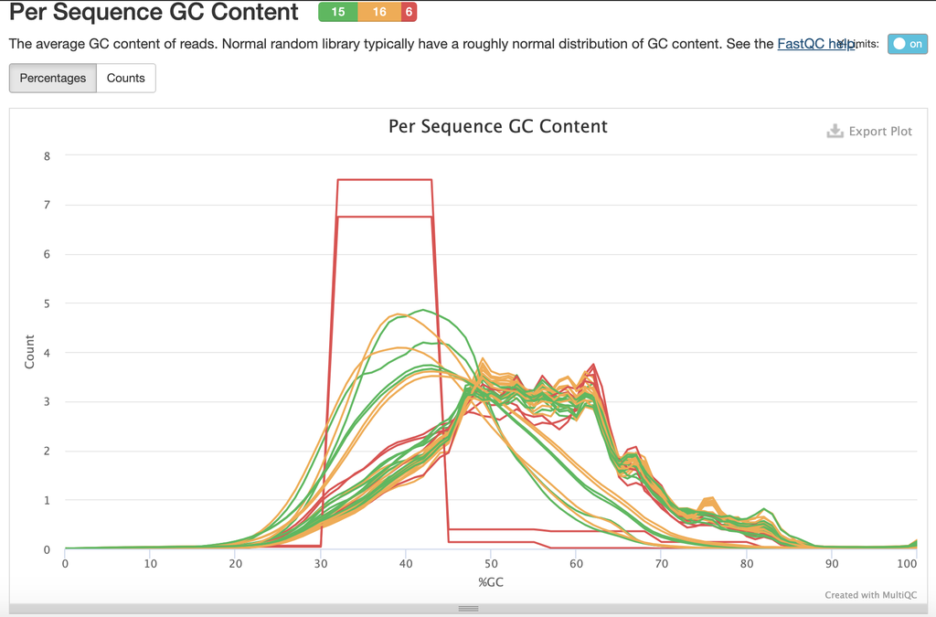

4. All the libraries have universal illumina adapter contamination, which will resolve with cutadapt.

## Trimming and mapping 1

I’ll use the fasta file that Elliott provided to generate four separate indexes. First, I created a conda environment with the versions of cutadapt and bowtie2 that Elliott used:

```bash
conda create -n enFeLV -c bioconda cutadapt=1.18 bowtie2=2.3.4.1
conda activate enFeLV
```

Then, generate indexes:

```bash
for fa in fasta_files/*.fasta; do
    bowtie2-build $fa ${fa%%.*};
done

mv fasta_files/*.bt2 data/
```

All fastq files **except** the two that failed are in the `data`/ directory. (Note: had to remove _ in Mischief_minus and Mischief_plus for code to work.)

## Trimming and mapping 2: Elliott’s script

Following Elliott’s script, which I modified for our RNAseq files, I trimmed the raw reads with cutadapt, then mapped them to the indexes generated above.

I made some errors in file renaming, which were easily fixed with a sed loop such as:

```bash
for f in *fc.fastq.gz; do mv "$f" "$(echo "$f" | sed s/L002R/L002_R/)"; done
```

Original job (id 7189207): 70G mem, 22 cpus-per-task, 10H (finished in 00:08:40) Second job (id 7190427) to map incorrectly named files: 70G, 22 cpus-per-task, 3H (finished in 00:01:04)

After this, I manually moved all the resulting files generated via this script to the results directory.

## Check trimmed files

Following trimming with cutadapt, we can double check that adapter content has been removed by re-running the `fastqc.sh` script and looking at the multiqc output. Even though we got warnings from cutadapt about our R2 libraries, all libraries now pass the adapter content flag (adapter content ≤0.1%).

However, GC content is unchanged. Maybe some contamination during library prep?

Per base sequence content isn’t great (probably a cutadapt issue).

Sequence duplication levels and overrepresented sequences results are confusing…for example, we would *expect* all libraries to fail sequence duplication, but a few samples don’t, which makes me think there’s a library issue. Specifically, the puma libraries are almost completely devoid of duplication. **Maybe this is because the same indexes were used for the puma and for DC4???**

There’s a high percentage of overrepresented sequences. It looks like this is mostly rRNA, so Elliott must have done a total RNA library prep.

Really I need to know more about the library prep and sequencing platform used.

## Read quantification

According to Elliott’s manuscript, he then visually identified mapped reads in Geneious, visually identified exFeLV reads (?), and confirmed exFeLV via tblastn. I’m not sure how he quantified reads?

For the purposes of the snRNA project, I only need to look at *uninfected* samples (N=11; 6 PBMCs, 5 fibroblast)

## Questions

1. Why was cutadapt -q run in single end mode?
2. I’m getting an error that the adapter sequences provided are incomplete. Specifically, adapter 2 (GATCGGAAGAGCACA) provided is preceded by A 95% of the time and generates an error:

```
      WARNING:
      The adapter is preceded by "A" extremely often.
      The provided adapter sequence could be incomplete at its 3' end.
```

To see where the errors are occurring, use grep to search and print the subsequent 3 lines:

```bash
grep -A 3 -B 1 "One or more of your adapter sequences may be incomplete" output-7189207 > cutadapt_warnings.txt
```

From this file, we can see that the error occurs for every R2 library, e.g.:

```
      WARNING:
          One or more of your adapter sequences may be incomplete.
          Please see the detailed output above.
      Command line parameters: --cores=20 -a AGATCGGAAGAGCGT /
      -a GATCGGAAGAGCACA -o 4438_S1_L002R2_002_fc.fastq.gz /
      4438_S1_L002R2_001_f.fastq.gz
```

3. What were the methods for library prep and sequencing?
4. Were the same indexes used for Mischief and DC4?
5. What were the methods for transcript quantification?